## Project 1: Investigation of the molecular basis of heterosis using proteomics and transcriptomics

### Correlations between expression heterosis and plant height heterosis

Utilizing a panel of fifteen diverse hybrids, I calculated the Pearson correlations between expression heterosis (hybrid/mid-parent protein expression) in seedling leaves and plant height heterosis (hybrid/mid-parent plant height) in adult plants. Ribosomal proteins were the most positively correlated protein groups, while stress-response proteins were the most negatively correlated, suggesting an altered growth-defense trade-off in hybrids. These expression patterns could be used as a seedling biomarker for hybrid performance in agriculture breeding programs. mRNA levels were less correlated with plant height than protein levels, indicating a role of post-transcriptional regulation in heterosis. In the figure below, density curves represent the Pearson correlations between expression heterosis and plant height heterosis for groups of proteins that were significantly correlated.

[Click here to view my publication of this work](https://www.pnas.org/doi/abs/10.1073/pnas.2109332118)

[Click here to try the shiny app I developed to find the correlation for your gene of interest!](https://devonbirdseye.shinyapps.io/ExpressionViewer/)

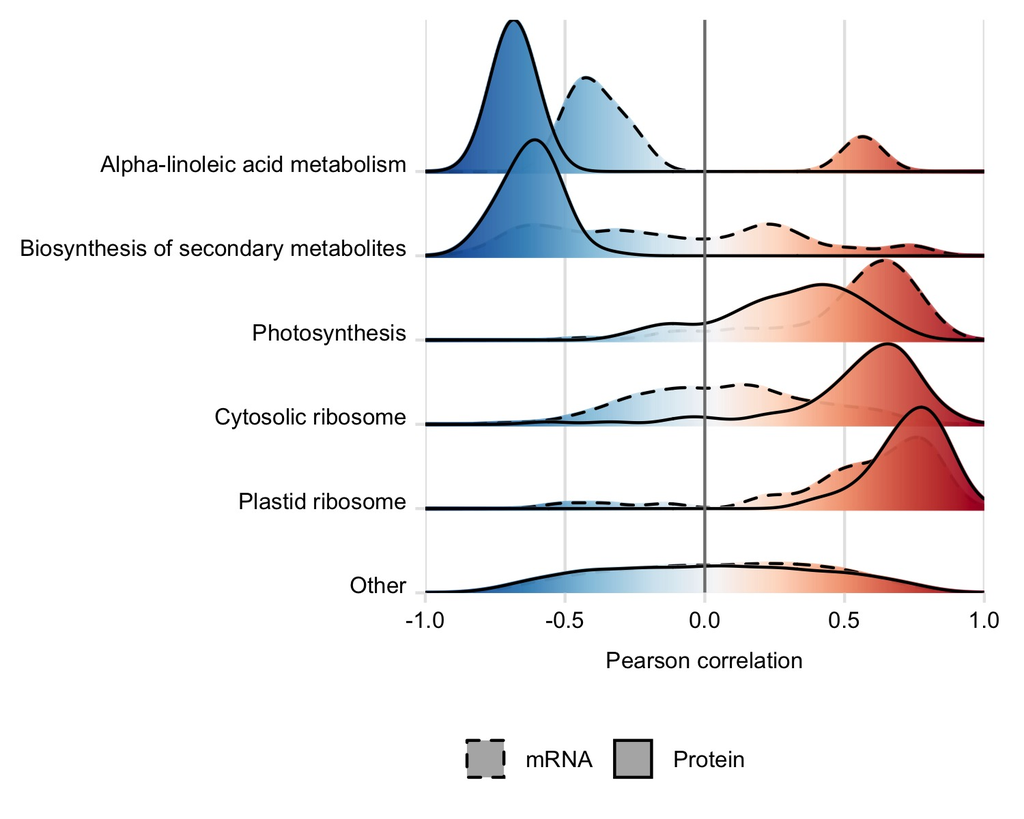

[Click here to view source code](https://github.com/devonbirdseye/devonbirdseye.github.io/blob/master/HeterosisCorrelations.R)

|  | ALA metabolism | Biosynthesis of secondary metabolites | Photosynthesis | Plastid ribosome | Cytosolic ribosome |
| --- | --- | --- | --- | --- | --- |
| mean (group) | -0.68177 | -0.62785 | 0.30685 | 0.73058 | 0.53629 |
| mean (others) | 0.03709 | 0.04647 | 0.03041 | 0.02780 | 0.02587 |
| SD (group) | 0.04615 | 0.08747 | 0.24210 | 0.11989 | 0.26428 |
| SD (others) | 0.40957 | 0.40465 | 0.41107 | 0.40526 | 0.40625 |
| p-value | 0.00000 | 0.00000 | 0.00000 | 0.00000 | 0.00000 |
| Z-statistic | -33.08255 | -49.94608 | 9.60219 | 36.05583 | 16.11687 |